# Fuzzy Quantification of Common and Rare Species in Ecological Communities (FuzzyQ)

Juan A. Balbuena, Clara Monlleó-Borrull, Cristina Llopis-Belenguer, Isabel Blasco-Costa, Volodimir L. Sarabeev, Serge Morand

02 November 2020

# FuzzyQ – Ant species example

We illustrate the use and capabilities of FuzzyQ with a dataset of ant species (ants_Darwin_A from Calatayud el al. (2019)). The dataset collates the abundance of 46 species in 100, 18 × 18 m plots sampled in the Northern Territory, Australia (Arnan et al., 2011).

```r
library(FuzzyQ)
data(antsA)     # loads the ant database (site-by-species abundance matrix)

FQAnts <- fuzzyq(antsA, sorting = TRUE)
```

Note that we set the argument `sorting = TRUE` to sort the species by cluster. This facilitates effective visualization of the rare and common species composition of the community. `FQAnts$A_O`, returns the AO information of each species. We use `AOplot` to show the AO relationship of the ant community (Fig. 1).

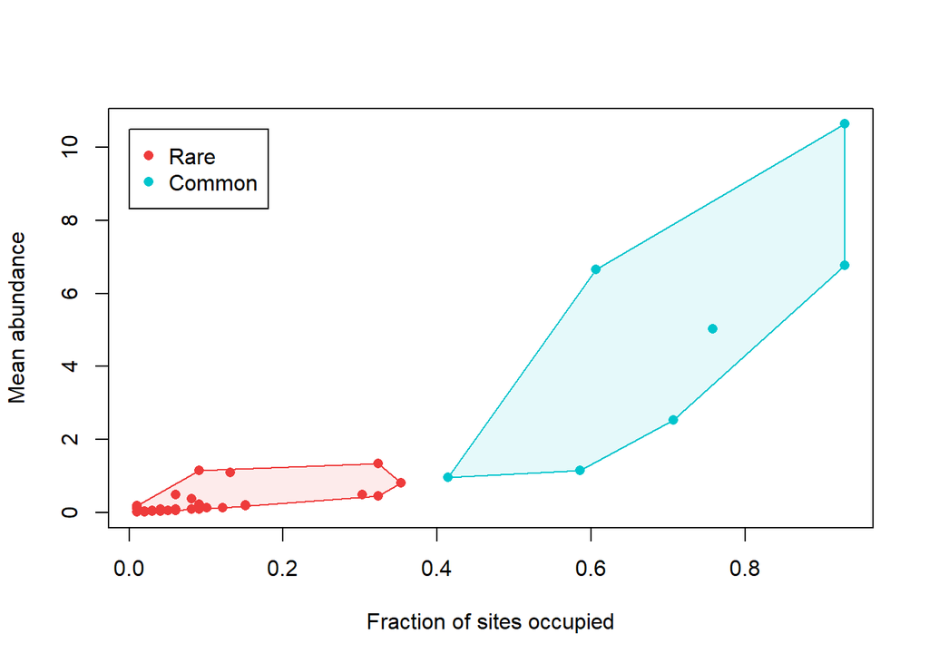

**Fig. 1.** Relationship between mean abundance and number of sites occupied of 46 ant species

```r
col.RC <- c("brown2", "turquoise3")
AOplot(FQAnts, col.RC, pch = 16)
legend(0, 10.5, c("Rare", "Common"), col = col.RC, pch = 16)
```

The allocation of species to clusters is stored in `FQAnts$spp`. Each species has been allocated to the rare (cluster = 0) or common cluster (cluster = 0 and 1, respectively):

```
##        cluster   sil_width   Common.I
## sps_15       0  0.49317392 0.45193394
## sps_8        0  0.51278584 0.43707371
## sps_45       0  0.62327350 0.36020316
## sps_35       0  0.65201657 0.33660336
## sps_18       0  0.80403066 0.17971997
## sps_19       0  0.83367067 0.14262525
## sps_29       0  0.86173265 0.11387856
## sps_36       0  0.86290322 0.11228338
## sps_23       0  0.89117336 0.07413132
## sps_10       0  0.90167855 0.05756174
## sps_20       0  0.90370956 0.05596081
## sps_5        0  0.90547644 0.05376546
## sps_14       0  0.90781862 0.05050306
## sps_9        0  0.91221695 0.04389605
## sps_4        0  0.91295943 0.04268709
## sps_39       0  0.91729545 0.03593477
## sps_25       0  0.91754402 0.03265451
## sps_1        0  0.92007954 0.02844395
## sps_13       0  0.92007954 0.02844395
## sps_26       0  0.92007954 0.02844395
## sps_28       0  0.92007954 0.02844395
## sps_40       0  0.92007954 0.02844395
## sps_41       0  0.92007954 0.02844395
## sps_43       0  0.92007954 0.02844395
## sps_44       0  0.92007954 0.02844395
## sps_34       0  0.92036413 0.02840823
## sps_22       0  0.92049340 0.02788790
## sps_12       0  0.92329475 0.02630374
## sps_46       0  0.92350710 0.02586522
## sps_7        0  0.92387440 0.02340876
## sps_11       0  0.92387440 0.02340876
## sps_17       0  0.92387440 0.02340876
## sps_6        0  0.92412791 0.02307659
## sps_30       0  0.92497786 0.02319410
## sps_37       0  0.92562230 0.02129898
## sps_2        0  0.92579517 0.02108267
## sps_42       0  0.92583965 0.02144117
## sps_24       0  0.92585524 0.02157493
## sps_21       0  0.92588366 0.02099071
## sps_27       1 -0.44650248 0.52553230
## sps_3        1  0.03065189 0.71356545
## sps_38       1  0.41606315 0.83454643
## sps_31       1  0.51494510 0.76967199
## sps_16       1  0.54938659 0.86063493
## sps_33       1  0.58273755 0.88190256
## sps_32       1  0.59717967 0.84314656
```

The silhouette widths (`sil_width`) displayed above measure how similar abundance and occupancy of each species are to its own cluster relative to species in the other cluster. A silhouette bar graphs informs of the nature of the community in terms of the distribution of common and rare species (Fig. 2).

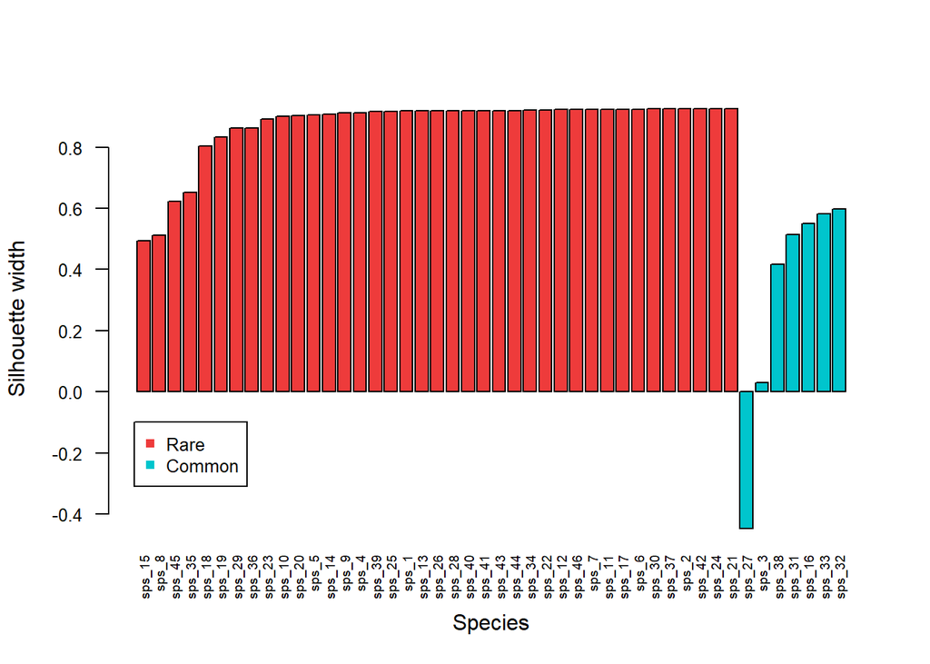

**Fig. 2.**Silhouettes of 46 ant species generated with a fuzzy clustering algorithm

```r
spp <- FQAnts$spp
barplot(spp[,2], names.arg=rownames(spp),
        col=col.RC[spp[,1]+1],
        las=2, cex.names=0.6, xlab="Species", ylab="Silhouette width",
        cex.axis = 0.8)
legend(0, -0.1, c("Rare", "Common"), col = col.RC, pch = 15, cex = 0.8)
```

Common ant species show smaller silhouettes, suggesting a weaker cluster and the negative silhouette of species 27 indicates a poor fit to the common-species group (Fig. 2).

`FQAnst$spp` also provides the commonness indices (`Common.I` above) that represent the probability of each species being common given the AO observed. We wish to plot these indices with their 95% confidence intervals. To this end, `fuzzyqBoot` generates ‘Nboot’ bootstrap replicates by site and `fuzzyqCI` estimates the confidence intervals based on the replicates:

```r
Nboot = 1e3
set.seed(2020) # Optional: setting set.seed to an arbitrary integer warrants
               # reproducibility of results
BS.FQAnts <- fuzzyqBoot(antsA, Nboot, level='spp')
BS.FQAnts <- fuzzyqCI(BS.FQAnts, fq=FQAnts, method="bca")
```

In this case we chose the `bca` (bias corrected and accelerated) method. Two additional methods, bias corrected (`method = "bc"`) and percentile (`method = "pct"`) are implemented in `fuzzyqCI`. Prior to plotting, the confidence intervals need to be sorted as per the species order in `FQAnts`:

```r
BS.FQAnts <- sortClus(BS.FQAnts, FQAnts)
```

Figure 3 shows the commonness indices and confidence intervals of each species in our dataset.

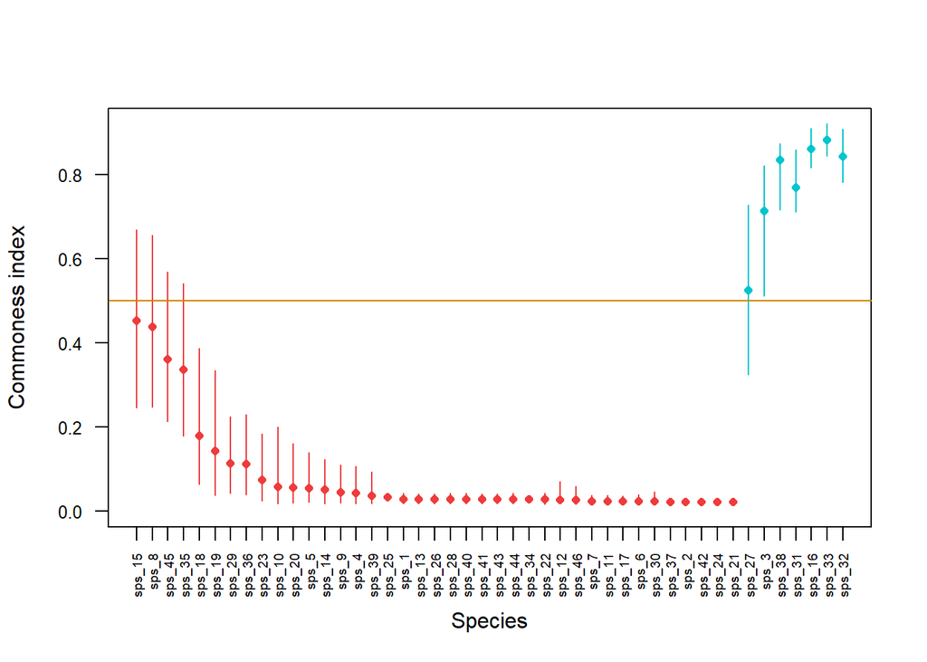

**Fig.3.** Commonness indices and 95% bootstrap confidence intervals of 46 ant species generated with a fuzzy clustering algorithm. The horizontal line indicates a commonness index of 0.5

```r
plot(spp[,3], cex.axis=0.8, xaxt='n', ylab="Commoness index",
     ylim=c(0, max(BS.FQAnts)), xlab="Species",col=col.RC[spp[,1]+1],
     pch=16, cex=0.8, las = 1)
ebar.int <- seq_len(nrow(spp)) # use arrows function to draw CIs:
arrows(ebar.int, BS.FQAnts["Lower", ], ebar.int, BS.FQAnts["Upper", ],
       length= 0, col=col.RC[spp[,1]+1])
abline(h=0.5, col="orange3",xpd=FALSE)
axis(1, at=ebar.int, labels=rownames(spp), las=2, cex.axis=0.6)
```

`FQAnts$global` provides several global parameters of the community. First, average silhouette widths and average commonness indices measure the strength of each cluster. Second, the global silhouette average value and the normalized Dunn’s index are metrics of the overall clustering structure (Kaufman & Rousseeuw, 1990). We can assess their variability based on 1,000 bootstrap replicates by site (Fig. 4)

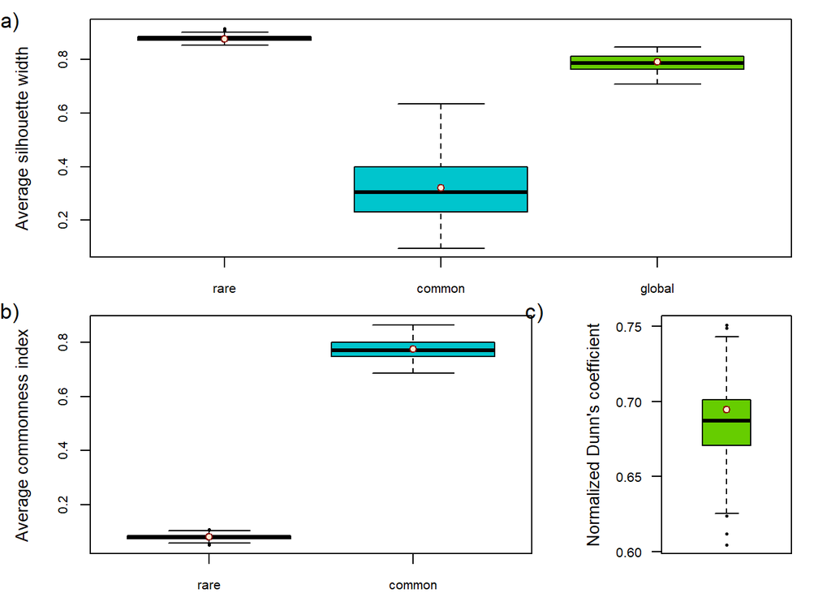

**Fig. 4.** Global clustering parameters of a community of 46 ant species generared with a fuzzy clustering algortihm. Boxplots represent the variation of 1,000 bootstrap replicates. Points correspond to the estimates of the database. a) Average silhouette widths of rare and common species and globally; b) Average Commonness Indices of rare and common species; c) Normalized Dunn’s index

```r
BS.global <- fuzzyqBoot (antsA, Nboot, level='global')
par(mar=c(2, 4.6, 1, 2))
layout(matrix(c(1,1,2,3), 2, 2, byrow = TRUE), widths=c(2.75,1.25),
       heights=c(1,1))
boxplot.matrix(BS.global$fq.rep[,1:3],  cex.axis=0.8,
               names=c("rare", "common", "global"),
               ylab="Average silhouette width",
               xlab="", col=c(col.RC,"chartreuse3"),
               pch=16, cex=0.4)
points(FQAnts$global[1:3], pch=21, col="darkred", bg="papayawhip")
mtext("a)", side=2, at=0.95, line=3.6, las=1, cex=1.1)
boxplot.matrix(BS.global$fq.rep[,4:5],  cex.axis=0.8,
               ylab="Average commonness index", names=c("rare", "common"),
               xlab="", col=col.RC,
               pch=16, cex=0.4)
points(FQAnts$global[4:5], pch=21, col="darkred", bg="papayawhip")
mtext("b)", side=2, at=0.92, line=3.6, las=1, cex=1.1)
mtext("c)", side=2, at=0.92, line=-23, las=1, cex=1.1)
boxplot(BS.global$fq.rep[,6], las=2, cex.axis=0.8,
        ylab="Normalized Dunn's coefficient",
        xlab="", col= "chartreuse3",
        pch=16, cex=0.4)
points(FQAnts$global[6], pch=21, col="darkred", bg="papayawhip")
```

Both the average global silhouette width and the normalized Dunn index observed suggest a strong clustering structure separating common and rare species (Kaufman & Rousseeuw, 1990). Compared with common ones, rare species showed a higher average silhouette width, a much lower average commonness coefficient and less variation, suggesting that they form a harder cluster (Fig. 4).

### References

Arnan, X., Gaucherel, C., & Andersen, A. N. (2011). Dominance and species co-occurrence in highly diverse ant communities: a test of the interstitial hypothesis and discovery of a three-tiered competition cascade. Oecologia, 166(3), 783–794. doi:10.1007/s00442-011-1919-y

Calatayud, J., Andivia, E., Escudero, A., Melián, C. J., Bernardo-Madrid, R., Stoffel, M., … Madrigal-González, J. (2019). Positive associations among rare species and their persistence in ecological assemblages. Nature Ecology & Evolution, 4(1), 40–45. doi:10.1038/s41559-019-1053-5

Kaufman, L., & Rousseeuw, P. J. (1990). Finding Groups in Data. Wiley Series in Probability and Statistics. John Wiley & Sons, Inc. doi:10.1002/9780470316801